[AKES Newsletter](http://www.akentsoc.org/newsletter.php) Volume 15, Issue 1, November 2022

# Corrections to the literature: Three recently published records for *Nicrophorus* (Coleoptera: Staphylinidae: Silphinae) deemed erroneous

*by Derek S. Sikes*[^1]

## Abstract

During the last decade three occurrence records for three species of *Nicrophorus*—*N. guttula,* from Sitka Alaska, USA, *N. hebes* from Alaska, and *N. hybridus* from Whitehorse, Yukon, Canada—were published, which are likely erroneous because no reliable evidence suggests these species occur or occurred in these regions. This short note provides details, comments, and species distribution modeling analyses on these records and concludes all three are erroneous.

## Introduction

Species of the genus *Nicrophorus*, commonly called burying beetles in North America, are relatively well known, large-bodied beetles (Anderson and Peck 1985) now in the family Staphylinidae (Cai et al. 2022). Despite peer-reviewed publications being the gold standard for reliable scientific information, errors do make it into print and, when found, are best corrected. Herein, three such records are addressed—while admitting the much greater difficulty of demonstrating the absence, relative to the presence, of a species from a region. One approach to this problem is to attempt to answer the question of whether the climate of a region is suitable for a species based on an understanding of the climate from where it is known to occur. Thus, a niche modeling, aka species distribution modeling, analysis was undertaken to help quantify the likelihood of two of these questionable records.

## Methods

### Species Distribution Modeling

The basics of the protocols in Oliver (2021) and Waraniak (2018) were followed using the 19 bioclimatic variables available from the WorldClim 2.0 database which contain the averages for the years 1970–2000 at 2.5 minutes resolution (~5 km) (Fick and Hijmans 2017). The bioclim (Nix 1986, Booth et al. 2014) model in the dismo 1.3-5 package (Hijmans et al. 2021) for R v.4.0.2 (R Core Team 2020) was used with the presence-only occurrence data for *N. hybridus* and *N. guttula*. The R script for the *N. guttula* analysis is provided as an appendix. The occurrence data files for the R analyses presented herein are available at https://doi.org/10.6084/m9.figshare.19401131. These data came from the collections and literature sources listed in Table 1. Those with DSS as the source are available in more complete form at http://dx.doi.org/10.5061/dryad.mr221 from Sikes and Venables (2013). Those with GBIF as the source are listed below in the literature cited as GBIF.org (2022c) and GBIF.org (2022a).

Table 1: Collections and literature from which data used herein were derived.

| Collection or Publication | Source |
| --- | --- |
| Albuquerque [MSBA] | GBIF |
| Anderson & Peck (1985) | literature |
| Backlund & Marrone (1997) | literature |
| Berkeley [EMEC] | DSS, GBIF |
| Boulder [UCM, UCMC] | GBIF |
| Budapest [HNHM] | DSS |
| Cambridge [MCZC] | DSS |
| Chicago [CHAS] | GBIF |
| Chicago [FMNH] | DSS, GBIF |
| Cincinnati [CMC] | GBIF |
| Cochrane [CEIC] | DSS |
| College Station [TAMU] | DSS, GBIF |
| Columbus [OSUC] | DSS |
| Denver [DMNS] | GBIF |
| Ebina -Nishikawa private coll [MNC] | DSS |
| Edinburgh [RSME] | DSS |
| Fairbanks [DSSC] | DSS |
| Fairbanks [UAM] | GBIF |
| Flagstaff [NAUF, CPMAB] | GBIF |
| Fort Collins [CSUC] | GBIF |
| Frankfurt [SMFD] | DSS |
| Hatch (1945) | Literature |
| iNaturalist | GBIF |
| Jalisco [CZUG] | GBIF |
| Las Cruces [NMSU] | GBIF |
| Los Angeles [LACM, IP] | GBIF |
| Los Angeles [LACM, RLB] | GBIF |
| Los Angeles [LACM] | DSS |
| Logan [EMUS] | DSS |
| New Haven [PMNH] | DSS |
| New York [AMNH] | DSS |
| Norman [OMNH, RINVRT] | GBIF |
| Ohio [OSUC] | GBIF |
| Peck & Anderson (1985) | Literature |
| Peck & Kaulbars (1987) | Literature |
| Philadelphia [ANSP] | DSS |
| Provo (BYUC) | DSS |
| San Diego [SDNHM] | GBIF |
| Santa Barbara [SBMNH] | GBIF |
| Santa Barbara [UCSB, IZC] | GBIF |
| St. Paul [UMSP] | DSS |
| Tempe [ASU, ASUHIC] | GBIF |
| Tempe [ASU, NEON-IV] | GBIF |
| University Park [PSUC] | GBIF |
| Vancouver [UBCZ] | GBIF |
| Washington D.C. [USNM] | DSS, GBIF |
| Wien [Wolfgang Barries Private Coll.] | DSS |

## Results

### *Nicrophorus hebes* Kirby

Based on molecular, ecological, breeding trial, and morphological data, Sikes et al. (2016) recognized this species as valid and elevated it to species status from a junior synonym under *Nicrophorus vespilloides* Herbst. *Nicrophorus hebes* is distritibuted widely within eastern and central Canada and, to date, there is no evidence that *Nicrophorus hebes* occurs west of about 120° longitude or north of about 61° latitude in the Nearctic. It is thus absent from northwestern Canada and Alaska. Nevertheless, this species was accidentally reported from Alaska by Meeds (2021) who, while reviewing literature relevant to forensic entomology for Alaska, misunderstood the information presented in Sikes et al. (2016).

### *Nicrophorus hybridus* Hatch & Angell

Backlund and Marrone (1997) reported *N. hybridus* from sandy grasslands and scattered cottonwood stands in South Dakota. Peck and Kaulbars (1987) reported this species from prairie, sage steppe, and montane meadow. Anderson and Peck (1985) indicated it occurs in prairies and dry inland valleys. The ecoregion data of Olson et al. (2001), as mapped in SimpleMappr (Shorthouse 2010) (data not shown), indicate it occurs primarily in grasslands, shrub steppe, montane and foothills forests and parklands east of the Rocky Mountains but some records are known from west of these mountains in coastal forest ecoregions—presumably in drier inland grassland and shrub valleys. All these habitats and climates are quite different from the subarctic boreal habitats of the Whitehorse region.

Using presence-only data for *N. hybridus* a niche model for this species was estimated which shows Whitehorse to have habitat unsuitable for this species (Figure 1), thus making it far more likely that the specimens in question were actually *N. investigator.*

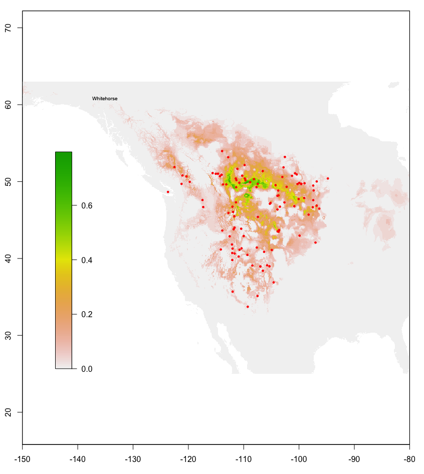

Figure 1: Map of records for *Nicrophorus hybridus* Hatch & Angell showing observations (red dots) and habitat suitability probability (colors, see key) based on presence-only niche modeling using the bioclim algorithm in the dismo package in R.

### *Nicrophorus guttula* Motschulsky

Bousquet et al. (2013) in their checklist of the beetles of Canada and Alaska, reported *N. guttula* from Alaska because the type locality of this species is Sitka, Alaska (57° N). Sikes et al. (2002) had addressed this issue and concluded the type locality was likely based on an error. Aside from the type locality description there have been no other records of this species reported from Sitka or anywhere in southeast Alaska, despite relatively extensive beetle collections having been made there, including 408 records of *Nicrophorus* from southeast Alaska—with the only *Nicrophorus* species being *N. investigator* and *N. defodiens* (GBIF.org 2022c). The northernmost, verified record (specimen identified by S. Peck) for *N. guttula* is from Riske Creek in southern British Columbia at 51.9° (GBIF.org 2022b). However, this northernmost record appears to be an outlier, because 97% of records are south of 50°N (Sikes and Venables 2013 (total *n* = 294), GBIF.org 2022a (total *n* = 1328)). Note that in Sikes and Venables (2013) there is a record from 55°N that, upon inspection, was revealed to be incorrectly georeferenced—its locality data said only “British Columbia” with no further geoprecision and it had thus been georeferenced to the approximate center of the province. I therefore deleted that record’s geocoordinates.

Using presence-only data for *N. guttula* a niche model for this species was estimated which shows southeast Alaska to have unsuitable habitat for this species (Figure 2), making the likelihood very low that the type locality of Sitka is correct. The correct type locality is presumably somewhere along the northwestern coast of California, Oregon, or Washington. Many beetle specimens from this coastline, and Alaska, made their way to Europe via Russian naturalists in the mid 1800s and confusion over collection data is quite plausible.

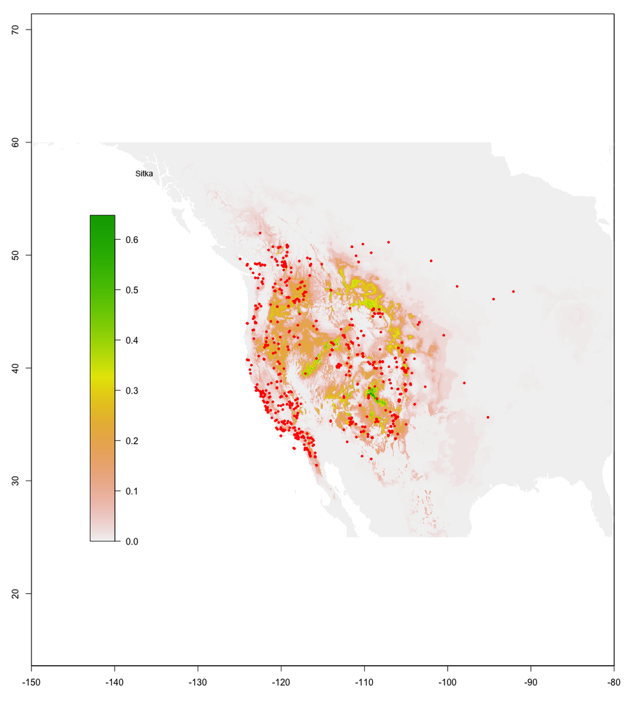

Figure 2: Map of records for *Nicrophorus guttula* Motschulsky showing observations (red dots) and habitat suitability probability (colors, see key) based on presence-only niche modeling using the bioclim algorithm in the dismo package in R.

Finally, how is it that this error was published in a work (Bousquet et al. 2013) on which I, a specialist on both the beetles of Alaska and the genus *Nicrophorus*, was a co-author? The answer is that the Alaskan record for this species was added to the draft, without consulting me, after I had finished and submitted my edits. Nevertheless, I was curious how likely such a record was and these analyses helped lay this question to rest.

## Acknowledgments

I thank the curators and collections staff who helped arrange loans of specimens for study from the collections listed in Table 1 and those who helped digitize data shared with GBIF.org, including those who submitted relevant iNaturalist observations.

## Appendix: R script for Niche Modeling

```r
# Species distribution modeling for Nicrophorus guttula
# Derek Sikes, dssikes@alaska.edu
# 2022-01-17

install.packages("dismo")
install.packages("maptools")
install.packages("rgdal")
install.packages("raster")
install.packages("sp")

library("sp")
library("raster")
library("maptools")
library("rgdal")
library("dismo")

# getData did not work to download the bioclimatic data from Worldclim so these were downloaded manually from https://www.worldclim.org/data/worldclim21.html they appeared in the following directory Users/dssikes/Downloads/wc2.1_2.5m_bio

> path <- file.path("/Users/dssikes/Downloads/wc2.1_2.5m_bio")
> files <- list.files(path, pattern='tif$', full.names=TRUE )
> files
 [1] "/Users/dssikes/Downloads/wc2.1_2.5m_bio/wc2.1_2.5m_bio_1.tif"
 [2] "/Users/dssikes/Downloads/wc2.1_2.5m_bio/wc2.1_2.5m_bio_10.tif"
 [3] "/Users/dssikes/Downloads/wc2.1_2.5m_bio/wc2.1_2.5m_bio_11.tif"
 [4] "/Users/dssikes/Downloads/wc2.1_2.5m_bio/wc2.1_2.5m_bio_12.tif"
 [5] "/Users/dssikes/Downloads/wc2.1_2.5m_bio/wc2.1_2.5m_bio_13.tif"
 [6] "/Users/dssikes/Downloads/wc2.1_2.5m_bio/wc2.1_2.5m_bio_14.tif"
 [7] "/Users/dssikes/Downloads/wc2.1_2.5m_bio/wc2.1_2.5m_bio_15.tif"
 [8] "/Users/dssikes/Downloads/wc2.1_2.5m_bio/wc2.1_2.5m_bio_16.tif"
 [9] "/Users/dssikes/Downloads/wc2.1_2.5m_bio/wc2.1_2.5m_bio_17.tif"
[10] "/Users/dssikes/Downloads/wc2.1_2.5m_bio/wc2.1_2.5m_bio_18.tif"
[11] "/Users/dssikes/Downloads/wc2.1_2.5m_bio/wc2.1_2.5m_bio_19.tif"
[12] "/Users/dssikes/Downloads/wc2.1_2.5m_bio/wc2.1_2.5m_bio_2.tif"
[13] "/Users/dssikes/Downloads/wc2.1_2.5m_bio/wc2.1_2.5m_bio_3.tif"
[14] "/Users/dssikes/Downloads/wc2.1_2.5m_bio/wc2.1_2.5m_bio_4.tif"
[15] "/Users/dssikes/Downloads/wc2.1_2.5m_bio/wc2.1_2.5m_bio_5.tif"
[16] "/Users/dssikes/Downloads/wc2.1_2.5m_bio/wc2.1_2.5m_bio_6.tif"
[17] "/Users/dssikes/Downloads/wc2.1_2.5m_bio/wc2.1_2.5m_bio_7.tif"
[18] "/Users/dssikes/Downloads/wc2.1_2.5m_bio/wc2.1_2.5m_bio_8.tif"
[19] "/Users/dssikes/Downloads/wc2.1_2.5m_bio/wc2.1_2.5m_bio_9.tif"

> predictors <- stack(files)
> predictors
class      : RasterStack
dimensions : 4320, 8640, 37324800, 19  (nrow, ncol, ncell, nlayers)
resolution : 0.04166667, 0.04166667  (x, y)
extent     : -180, 180, -90, 90  (xmin, xmax, ymin, ymax)
crs        : +proj=longlat +datum=WGS84 +no_defs
names      : wc2.1_2.5m_bio_1, wc2.1_2.5m_bio_10, wc2.1_2.5m_bio_11, wc2.1_2.5m_bio_12, wc2.1_2.5m_bio_13, wc2.1_2.5m_bio_14, wc2.1_2.5m_bio_15, wc2.1_2.5m_bio_16, wc2.1_2.5m_bio_17, wc2.1_2.5m_bio_18, wc2.1_2.5m_bio_19, wc2.1_2.5m_bio_2, wc2.1_2.5m_bio_3, wc2.1_2.5m_bio_4, wc2.1_2.5m_bio_5, ...
min values :       -54.759167,        -38.162666,        -66.380669,          0.000000,          0.000000,          0.000000,          0.000000,          0.000000,          0.000000,          0.000000,          0.000000,         1.000000,         9.063088,         0.000000,       -30.760000, ...
max values :         31.16667,          38.50467,          29.29167,       11246.00000,        2768.00000,         507.00000,         230.69151,        6174.00000,        1560.00000,        5608.00000,        5230.00000,         21.97300,        100.00000,       2377.62402,         48.46000, ...

# the Nicrophorus guttula data were taken from the data prepared for Sikes and Venables (2013) and GBIF.org (2022c). These were prepared as a .csv file with two columns of data separated by a comma (decimalLongitude, decimalLatitude). Note that R will throw an error if the first column is latitude and the second is longitude - these must be reversed. The following loads the observed data.

> guttula <- read.csv("~/Documents/ ALASKA/ PROJECTS/2022-AKES-Nicro corrections/niche modeling attempts/GBIFandDSS guttula data/guttula.csv")
>   View(guttula)

# the following builds the model by using climate data from the observed records

> obspred <- extract(predictors, guttula)  # extracts bioclim data for each of our data points
> bioclim.model <- bioclim(obspred)
> predictions <- predict(predictors, bioclim.model)

# the following makes the map of the modeled expected distribution

> plot(predictions, xlim=c(-150, -80), ylim=c(25, 60))

# the following adds the observed data to the expected on the map
> points(guttula, col = "red", pch = 20, cex = 0.75)
```

## References

Anderson RS, Peck SB (1985) The carrion beetles of Canada and Alaska. Coleoptera: Silphidae and Agyrtidae. (Insects and Arachnids of Canada, Part 13). Ottawa, Canada: Canadian Government Pub. Centre, Supply and Services Canada: 1–121.

Backlund DC, Marrone GM (1997) New records of the endangered American burying beetle, Nicrophorus americanus Olivier, (Coleoptera: Silphidae) in South Dakota. The Coleopterists Bulletin 51: 53–58.

Booth TH, Nix HA, Busby JR, Hutchinson MF (2014) BIOCLIM: The first species distribution modelling package, its early applications and relevance to most current MAXENT studies. Diversity and Distributions 20: 1–9.

Bousquet Y, Bouchard P, Davies AE, Sikes DS (2013) Checklist of Beetles (Coleoptera) of Canada and Alaska. Second Edition. Pensoft Series Faunistica No 109, Sofia-Bulgaria, 402 pp. ISSN 1312-0174, ISBN 978-954-642-704-5.

Bygarski K, LeBlanc HN (2013) Decomposition and Arthropod Succession in Whitehorse, Yukon Territory, Canada. Journal of Forensic Sciences 58: 413–418. https://doi.org/10.1111/1556-4029.12032

Cai C, Tihelka E, Giacomelli M, Lawrence JF, Ślipiński A, Kundrata R, Yamamoto S, Thayer MK, Newton AF, Leschen RAB, Gimmel ML, Lü L, Engel MS, Bouchard P, Huang D, Pisani D, Donoghue PCJ (2022) Integrated phylogenomics and fossil data illuminate the evolution of beetles. Royal Society Open Science 9: 211771. https://doi.org/10.1098/rsos.211771

Fick SE, Hijmans RJ (2017) WorldClim 2: New 1km spatial resolution climate surfaces for global land areas. International Journal of Climatology 37: 4302–4315.

GBIF.org (2022a) Occurrence download. https://doi.org/10.15468/DL.44ZMQ2

GBIF.org (2022b) Occurrence download. https://doi.org/10.15468/DL.6UHRWM

GBIF.org (2022c) Occurrence download. https://doi.org/10.15468/DL.YFNK6B

Hijmans RJ, Phillips S, Leathwick J, Elith J (2021) dismo: Species distribution modeling. Available from: https://CRAN.R-project.org/package=dismo.

Meeds AW (2021) A review of forensic entomology literature in Alaska, United States. Forensic Science 3: e1413.

Nix HA (1986) A biogeographic analysis of Australian elapid snakes. Atlas of elapid snakes of Australia: Australian flora and fauna series 7 (ed. By R. Longmore). In: Bureau of Flora and Fauna, Canberra., 4–15.

Oliver J (2021) A very brief introduction to species distribution models in R. Available from: https://jcoliver.github.io/learn-r/011-species-distribution-models.html.

Olson DM, Dinerstein E, Wikramanayake ED, Burgess ND, Powell GVN, Underwood EC, D’amico JA, Itoua I, Strand HE, Morrison JC, Loucks CJ, Allnutt TF, Ricketts TH, Kura Y, Lamoreux JF, Wettengel WW, Hedao P, Kassem KR (2001) Terrestrial Ecoregions of the World: A New Map of Life on Earth. BioScience 51: 933. https://doi.org/10.1641/0006-3568(2001)051[0933:TEOTWA]2.0.CO;2

Peck SB, Kaulbars MM (1987) A synopsis of the distribution and bionomics of the carrion beetles (Coleoptera: Silphidae) of the conterminous United States. Proceedings of the Entomological Society of Ontario 118: 47–81.

R Core Team (2020) R: A language and environment for statistical computing. R Foundation for Statistical Computing, Vienna, Austria. Available from: https://www.R-project.org/.

Sampson A, Sikes DS (2020) A Preliminary Forensic Entomological Study of Beetles (Coleoptera) in Interior Alaska, USA. Journal of Forensic Sciences 65: 2030–2035. https://doi.org/10.1111/1556-4029.14523

Shorthouse DP (2010) SimpleMappr, an online tool to produce publication-quality point maps. Available from: http://www.simplemappr.net.

Sikes DS, Venables C (2013) Molecular phylogeny of the burying beetles (Coleoptera: Silphidae: Nicrophorinae). Molecular Phylogenetics and Evolution 69: 552–565. https://doi.org/10.1016/j.ympev.2013.07.022

Sikes DS, Madge RB, Newton AF (2002) A catalog of the Nicrophorinae (Coleoptera: Silphidae) of the world. Zootaxa 65: 1. https://doi.org/10.11646/zootaxa.65.1.1

Sikes DS, Trumbo ST, Peck SB (2016) Cryptic diversity in the New World burying beetle fauna: *Nicrophorus hebes* Kirby, 1837; new status as a resurrected name (Coleoptera: Silphidae: Nicrophorinae). Arthropod Systematics & Phylogeny 74: 299–309. Available from: https://www.senckenberg.de/wp-content/uploads/2019/08/05_asp_74_3_sikes_299-309.pdf.

Stafford R, Hart AG, Goodenough AE (2013) A visual method to identify significant latitudinal changes in species’ distributions. Ecological Informatics 15: 74–84.

Waraniak J (2018) Species Distribution Modeling in R Tutorial. Available from: https://www.youtube.com/watch?v=1C1zVJO-Rk0.

[^1]: University of Alaska Museum, 1962 Yukon Dr., University of Alaska Fairbanks, Fairbanks, AK 99775, dssikes@alaska.edu